# Lab 06, Experiment 3

# Matched Filters and ISI

**Devise a test using pam12.m, pamrcvr10.m, and showeye.m to determine for which of the 16pulse types (’man’, ’rcf’, ’rect’, ’rrcf’, ’sinc’, ’tri’) there is ISI (intersymbol interference) either in the received PAM signal r(t) and/or in the signal b(t) after the matched filter. If there is ISI, estimate (in percent of the full size) by how much the “eye” in the eye diagram gets closed because of ISI.**

```python
%matplotlib inline
```

```python
# Importing all required modules

from pylab import *
import pam12 as pam
import showfun as sf
import wavfun as wf
import filtfun as ff
import ascfun as af
```

**i) Eye-diagram analysis of 'rect' pulse**

```python
an = af.asc2bin('I failed MyTest')                          # Generating a sequence of zero and ones
dn = 2*an-1
FB = 100
Fs = 44100
ptype = 'rect'
pparms=[]
```

```python
tt,rt = pam.pam12(dn,FB,Fs,ptype,pparms)
```

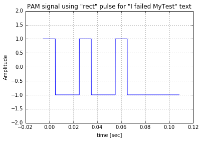

```python
plot(tt[0:5000],rt[0:5000])
xlabel('time [sec]')
ylabel('Amplitude')
title('PAM signal using "rect" pulse for "I failed MyTest" text')
ylim(-2,2)
grid()
```

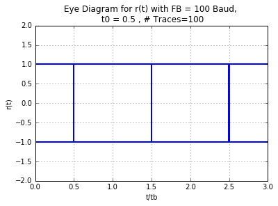

```python
sf.showeye(rt,Fs,FB,NTd = 100, dispparms=[0.5,3,-2,2])
```

```python
FBparms = [FB,0]
bn,bt,ixn=pam.pamrcvr10(tt,rt,FBparms, ptype, pparms=[])
```

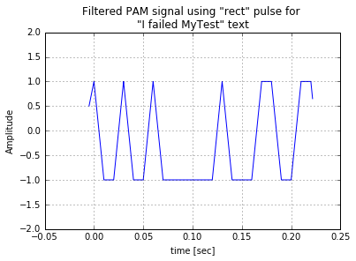

```python
plot(tt[0:10000],bt[0:10000])
xlabel('time [sec]')
ylabel('Amplitude')
title('Filtered PAM signal using "rect" pulse for \n"I failed MyTest" text')
ylim(-2,2)
grid()
```

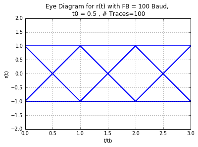

```python
sf.showeye(bt,Fs,FB,NTd = 100, dispparms=[0.5,3,-2,2])
```

**Analysis of eye diagrams of signal and the filtered signal: It can be observed that there is no ISI at t=nTB in both the signals. But, there is ISI at t!=nTB in matched filtered signal b(t) as we can see in its eye diagram. The eye gets closed by approximately 50% because of ISI (at time instances other than nTB) in b(t).**

**ii) Eye-diagram analysis of 'man' pulse**

```python
an = af.asc2bin('I failed MyTest')                          # Generating a sequence of zero and ones
dn = 2*an-1
FB = 100
Fs = 44100
ptype = 'man'
pparms=[]
```

```python
tt,rt = pam.pam12(dn,FB,Fs,ptype,pparms)
```

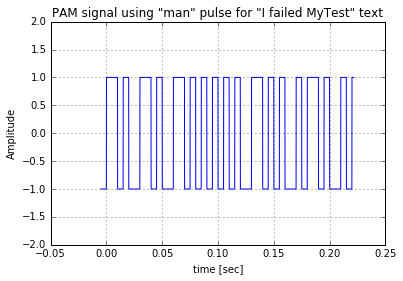

```python
plot(tt[0:10000],rt[0:10000])
xlabel('time [sec]')
ylabel('Amplitude')
title('PAM signal using "man" pulse for "I failed MyTest" text')
ylim(-2,2)
grid()
```

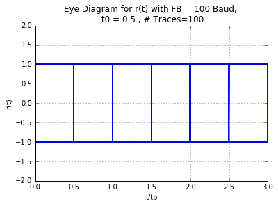

```python
sf.showeye(rt,Fs,FB,NTd = 100, dispparms=[0.5,3,-2,2])
```

```python
FBparms = [FB,0]
bn,bt,ixn=pam.pamrcvr10(tt,rt,FBparms, ptype, pparms=[])
```

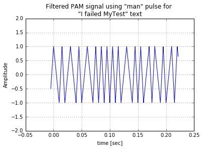

```python
plot(tt[0:10000],bt[0:10000])
xlabel('time [sec]')
ylabel('Amplitude')
title('Filtered PAM signal using "man" pulse for \n"I failed MyTest" text')
ylim(-2,2)
grid()
```

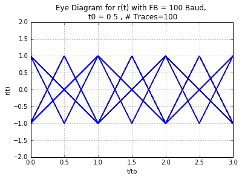

```python
sf.showeye(bt,Fs,FB,NTd = 100, dispparms=[0.5,3,-2,2])
```

**analysis of eye diagrams of signal and filtered signal using 'man' pulse: it can be observed that there is no ISI at t=nTB in both signals. However, there is ISI at all other time instances in b(t).**

**iii) Eye-diagram analysis of 'sinc' pulse**

```python
an = af.asc2bin('I failed MyTest')                          # Generating a sequence of zero and ones
dn = 2*an-1
FB = 100
Fs = 44100
ptype = 'sinc'
pparms=[10,0.2]
```

```python
tt,rt = pam.pam12(dn,FB,Fs,ptype,pparms)
```

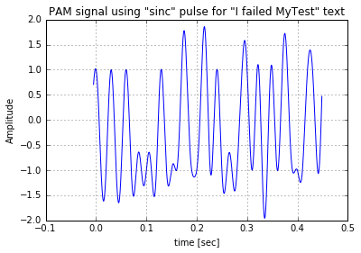

```python
plot(tt[0:20000],rt[0:20000])
xlabel('time [sec]')
ylabel('Amplitude')
title('PAM signal using "sinc" pulse for "I failed MyTest" text')
ylim(-2,2)
grid()
```

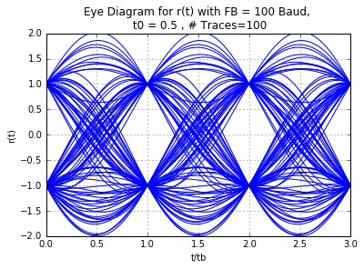

```python
sf.showeye(rt,Fs,FB,NTd = 100, dispparms=[0.5,3,-2,2])
```

```python
FBparms = [FB,0]
bn,bt,ixn=pam.pamrcvr10(tt,rt,FBparms, ptype, pparms=[10,0.2])
```

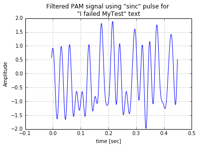

```python
plot(tt[0:20000],bt[0:20000])
xlabel('time [sec]')
ylabel('Amplitude')
title('Filtered PAM signal using "sinc" pulse for \n"I failed MyTest" text')
ylim(-2,2)
grid()
```

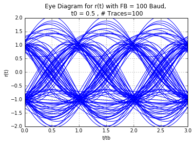

```python
sf.showeye(bt,Fs,FB,NTd = 100, dispparms=[0.5,3,-2,2])
```

**iv) Eye-diagram analysis of 'tri' pulse**

```python
an = af.asc2bin('I failed MyTest')                          # Generating a sequence of zero and ones
dn = 2*an-1
FB = 100
Fs = 44100
ptype = 'tri'
pparms=[]
```

```python
tt,rt = pam.pam12(dn,FB,Fs,ptype,pparms)
```

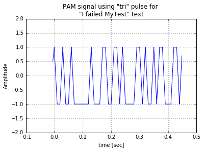

```python
plot(tt[0:20000],rt[0:20000])
xlabel('time [sec]')
ylabel('Amplitude')
title('PAM signal using "tri" pulse for \n"I failed MyTest" text')
ylim(-2,2)
grid()
```

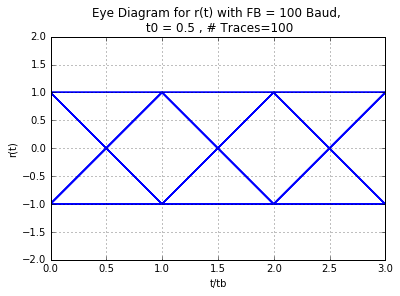

```python
sf.showeye(rt,Fs,FB,NTd = 100, dispparms=[0.5,3,-2,2])
```

```python
FBparms = [FB,0]
bn,bt,ixn=pam.pamrcvr10(tt,rt,FBparms, ptype, pparms=[10,0.2])
```

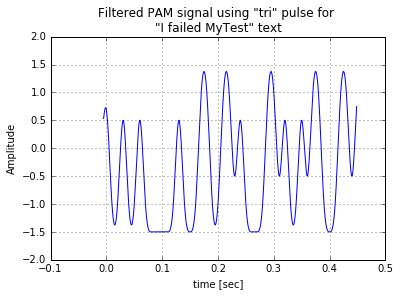

```python
plot(tt[0:20000],bt[0:20000])
xlabel('time [sec]')
ylabel('Amplitude')
title('Filtered PAM signal using "tri" pulse for \n"I failed MyTest" text')
ylim(-2,2)
grid()
```

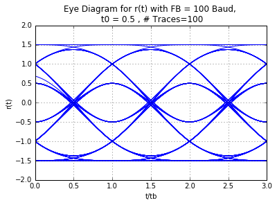

```python
sf.showeye(bt,Fs,FB,NTd = 100, dispparms=[0.5,3,-2,2])
```

**Analysis of the eye diagram of signal and filtered signal using 'tri' pulse: It can be seen in the eye diagram of r(t) and b(t) that there is no ISI at t=nTB in r(t) while there is ISI in the filtered signal b(t) at t =nTB. The eye in b(t) gets closed by approximately 50% at t=nTB because of ISI.**

**v) Eye-diagram analysis of 'rcf' pulse**

```python
an = af.asc2bin('I failed MyTest')                          # Generating a sequence of zero and ones
dn = 2*an-1
FB = 100
Fs = 44100
ptype = 'rcf'
pparms=[5,0.2]
```

```python
tt,rt = pam.pam12(dn,FB,Fs,ptype,pparms)
```

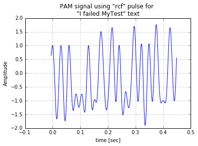

```python
plot(tt[0:20000],rt[0:20000])
xlabel('time [sec]')
ylabel('Amplitude')
title('PAM signal using "rcf" pulse for \n"I failed MyTest" text')
ylim(-2,2)
grid()
```

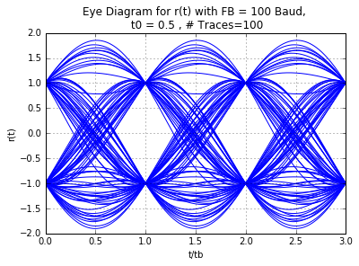

```python
sf.showeye(rt,Fs,FB,NTd = 100, dispparms=[0.5,3,-2,2])
```

```python
FBparms = [FB,0]
bn,bt,ixn=pam.pamrcvr10(tt,rt,FBparms, ptype, pparms=[10,0.2])
```

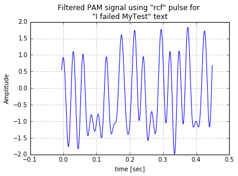

```python
plot(tt[0:20000],bt[0:20000])
xlabel('time [sec]')
ylabel('Amplitude')
title('Filtered PAM signal using "rcf" pulse for \n"I failed MyTest" text')
ylim(-2,2)
grid()
```

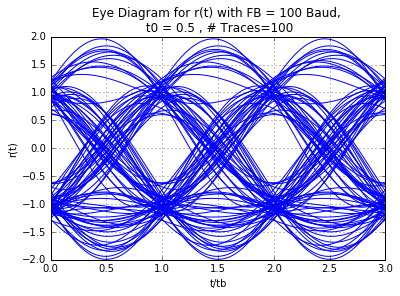

```python
sf.showeye(bt,Fs,FB,NTd = 100, dispparms=[0.5,3,-2,2])
```

**vi) Eye-diagram analysis of 'rrcf' pulse**

```python
an = af.asc2bin('I failed MyTest')                          # Generating a sequence of zero and ones
dn = 2*an-1
FB = 100
Fs = 44100
ptype = 'rrcf'
pparms=[5,0.2]
```

```python
tt,rt = pam.pam12(dn,FB,Fs,ptype,pparms)
```

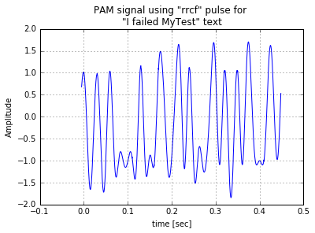

```python
plot(tt[0:20000],rt[0:20000])
xlabel('time [sec]')
ylabel('Amplitude')
title('PAM signal using "rrcf" pulse for \n"I failed MyTest" text')
ylim(-2,2)
grid()
```

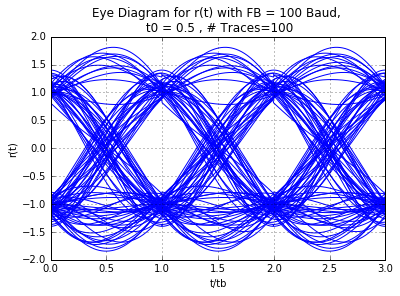

```python
sf.showeye(rt,Fs,FB,NTd = 100, dispparms=[0.5,3,-2,2])
```

```python
FBparms = [FB,0]
bn,bt,ixn=pam.pamrcvr10(tt,rt,FBparms, ptype, pparms=[10,0.2])
```

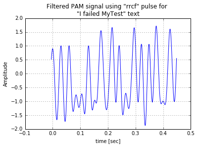

```python
plot(tt[0:20000],bt[0:20000])
xlabel('time [sec]')
ylabel('Amplitude')
title('Filtered PAM signal using "rrcf" pulse for \n"I failed MyTest" text')
ylim(-2,2)
grid()
```

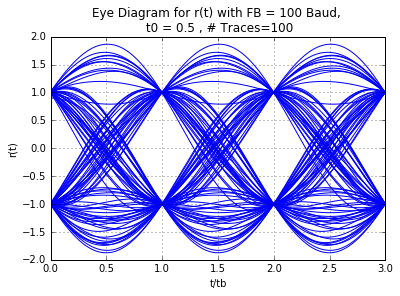

```python
sf.showeye(bt,Fs,FB,NTd = 100, dispparms=[0.5,3,-2,2])
```

**Analysis of the eye diagram of signal and filtered signal using 'rrcf' pulse: It can be seen that there is ISI at t=nTB in r(t) while there is no ISI in the filtered signal b(t) at t =nTB. The eye in r(t) gets closed by approximately 10% at t=nTB because of ISI.**